# Predicting Habitat Suitability and Niche Overlap in California Endemics

Spatial Data Exploration

2026-03-12

# Executive Summary

Ecological Niche Modeling (ENM) is a powerful spatial analysis tool used to understand the environmental drivers of species distributions. This project investigates the climatic niches of two California endemic species: the threatened California red-legged frog (Rana draytonii) and the historically extirpated California grizzly bear (Ursus arctos californicus).

By combining species occurrence records with spatial climate data, this analysis utilizes Generalized Linear Models (GLMs) and Bioclimatic envelope modeling to predict habitat suitability, project ranges under future climate scenarios (2070), and quantify historical niche overlap.

# 1. Environment Setup and Data Ingestion

This project utilizes the modern spatial R stack: sf for high-performance vector geometries and terra for rapid raster processing. We also use tigris and geodata to dynamically fetch highly accurate, reproducible administrative boundaries and climate data via APIs.

```r
# Load modern spatial libraries
library(sf)
library(terra)
library(dismo)
library(tigris)  # For dynamic boundary data
library(geodata) # For dynamic WorldClim climate data
library(corrplot) # For EDA visualization
library(usdm)     # For automated collinearity filtering
```

We ingest the species occurrence points, convert them into spatial objects, and establish our study area boundary.

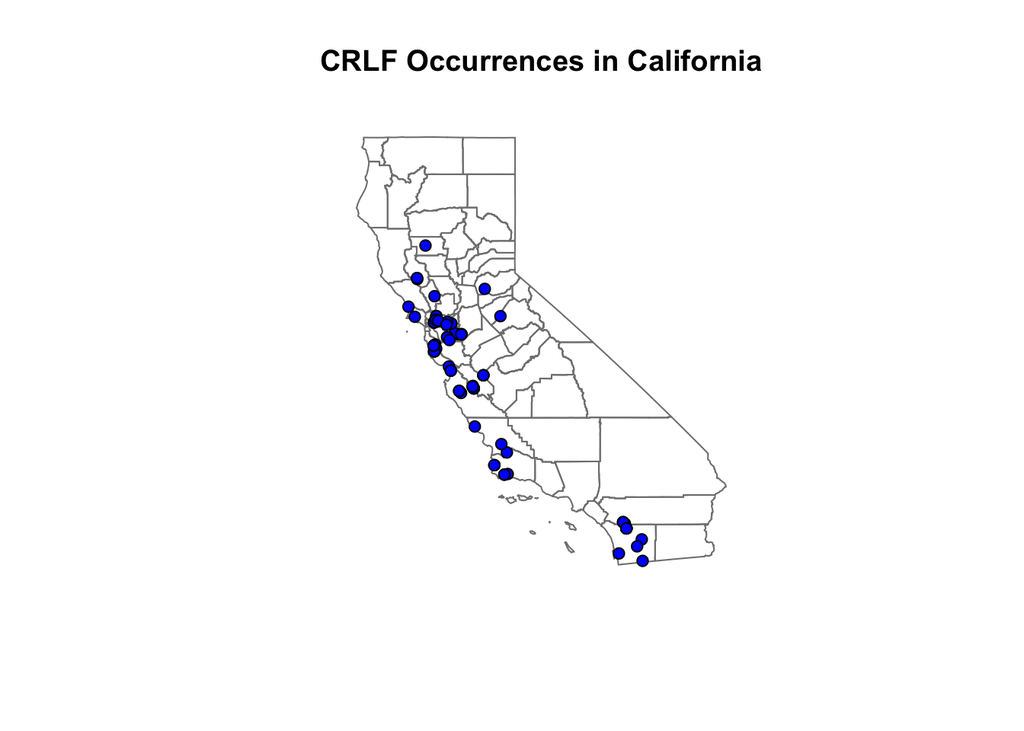

```r
# Fetch California county boundaries dynamically
options(tigris_use_cache = TRUE)
counties <- counties(state = "CA", cb = TRUE, class = "sf", progress_bar = FALSE)
counties <- st_transform(counties, crs = 4326)

# Load CRLF occurrence points and convert to spatial sf object
CRLF.df <- read.csv("Rana_draytonii.csv")
CRLF.occ <- st_as_sf(CRLF.df, coords = c("longitude", "latitude"), crs = 4326)

# Visualize the baseline occurrences
plot(st_geometry(counties), border = "gray50", main = "CRLF Occurrences in California")
plot(st_geometry(CRLF.occ), pch = 21, bg = "blue", add = TRUE)
```

# 2. Background Sampling & Environmental Covariates

Predictive models require both presence and absence data to establish constraints. We generate random pseudo-absence (background) points across California using native sf sampling.

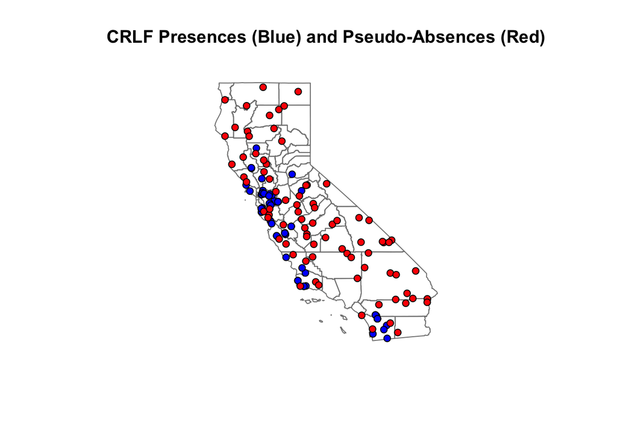

```r
set.seed(123)
CRLF.abs <- st_sample(counties, size = nrow(CRLF.occ), type = "random")

plot(st_geometry(counties), border = "gray50", main = "CRLF Presences (Blue) and Pseudo-Absences (Red)")
plot(st_geometry(CRLF.occ), pch = 21, bg = "blue", add = TRUE)
plot(CRLF.abs, pch = 21, bg = "red", add = TRUE)
```

We extract 19 continuous environmental covariates from the WorldClim database to serve as our initial model predictors.

```r
# Dynamically download present-day WorldClim bioclimatic variables
wclim_global <- worldclim_global(var = "bio", res = 2.5, path = tempdir())
names(wclim_global) <- paste0("bio", 1:19)

# Mask and crop the global raster stack to the California boundary
wclim <- mask(crop(wclim_global, vect(counties)), vect(counties))
```

In this case, rather than modeling all 19 variables, we subset to 6 which are ecologically relevant:

- bio1: Annual Mean Temperature
- bio2: Mean Diurnal Temperature Range
- bio7: Annual Temperature Range
- bio12: Annual Precipitation
- bio15: Precipitation Seasonality
- bio16: Precipitation of Wettest Quarter

```r
# A Priori Variable Selection:

# predictors driving amphibian and mammal distribution (temperature limits & precipitation constraints).
wclim <- subset(wclim, c("bio1", "bio2", "bio7", "bio12", "bio15", "bio16"))

# Extract raster values at our presence and absence locations
env.pres <- terra::extract(wclim, vect(CRLF.occ), ID = FALSE)
env.abs <- terra::extract(wclim, vect(CRLF.abs), ID = FALSE)

# Construct a unified modeling dataframe
env.pres$occ <- 1
env.abs$occ <- 0
env <- rbind(env.pres, env.abs)
```

# 3. Exploratory Data Analysis: Assessing Collinearity

While our initial 6 variables are ecologically justified, feeding highly correlated predictors into a Generalized Linear Model (GLM) inflates variance and causes multicollinearity. We first visualize the correlation matrix across our selected variables.

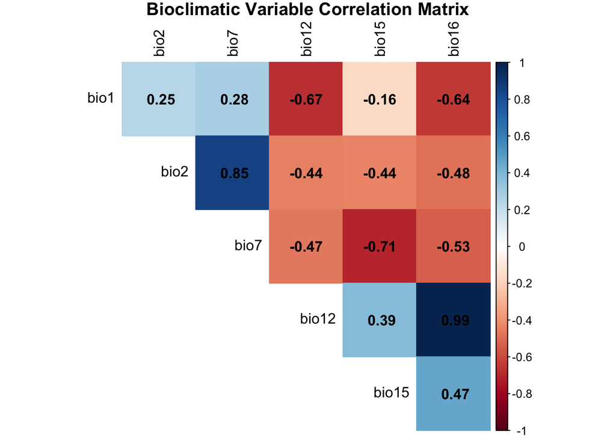

```r
# Calculate the correlation matrix (excluding the 'occ' presence/absence column)
cor_matrix <- cor(env[ , -which(names(env) == "occ")])

# Plot a professional heatmap
corrplot(cor_matrix, method = "color", type = "upper",
         tl.col = "black", tl.cex = 1, diag = FALSE,
         addCoef.col = "black", # This adds the actual correlation numbers to the squares!
         title = "Bioclimatic Variable Correlation Matrix",
         mar = c(0,0,1,0))
```

## Automated Variable Selection (VIF)

To ensure a parsimonious model devoid of human bias, we utilize the Variance Inflation Factor (VIF) algorithm from the usdm package. We set a strict correlation threshold of 0.7 to iteratively filter redundant variables from our ecologically informed subset.

```r
# Identify highly correlated variables and flag them for removal
vif_results <- vifcor(wclim, th = 0.7)

# Extract the names of the statistically safe variables
safe_vars <- vif_results@results$Variables
cat("Uncorrelated variables dynamically selected for modeling:\n", paste(safe_vars, collapse = ", "))
```

```
## Uncorrelated variables dynamically selected for modeling:
##  bio1, bio2, bio12, bio15
```

```r
# Automatically subset our raster stack and dataframe to ONLY include these safe variables
wclim <- usdm::exclude(wclim, vif_results)
env <- env[ , c("occ", safe_vars)]
```

While Precipitation of the Wettest Quarter (bio16) is a known driver for amphibians, its high collinearity with Annual Precipitation (bio12) in California necessitated its removal to ensure model parsimony. Bio12 was retained as a more comprehensive metric of total water availability.

# 4. Habitat Suitability Modeling (GLM)

We formulate a Generalized Linear Model (GLM) to determine how our statistically refined suite of bioclimatic variables influences the probability of occurrence.

```r
# Dynamically construct the GLM formula using our safe variables
glm_formula <- as.formula(paste("occ ~", paste(safe_vars, collapse = " + ")))

# Fit the optimized Generalized Linear Model
CRLF.enm <- glm(glm_formula, family = binomial(link = "logit"), data = env)
summary(CRLF.enm)
```

```
##
## Call:
## glm(formula = glm_formula, family = binomial(link = "logit"),
##     data = env)
##
## Coefficients:
##               Estimate Std. Error z value Pr(>|z|)
## (Intercept) -7.6188988  3.8457032  -1.981   0.0476 *
## bio1         0.0271321  0.1206654   0.225   0.8221
## bio2        -0.1991083  0.1107170  -1.798   0.0721 .
## bio12       -0.0007762  0.0008508  -0.912   0.3616
## bio15        0.1241126  0.0303320   4.092 4.28e-05 ***
## ---
## Signif. codes:  0 '***' 0.001 '**' 0.01 '*' 0.05 '.' 0.1 ' ' 1
##
## (Dispersion parameter for binomial family taken to be 1)
##
##     Null deviance: 224.58  on 161  degrees of freedom
## Residual deviance: 166.98  on 157  degrees of freedom
## AIC: 176.98
##
## Number of Fisher Scoring iterations: 6
```

## Model Evaluation

We evaluate model performance using Receiver Operating Characteristic (ROC) metrics.

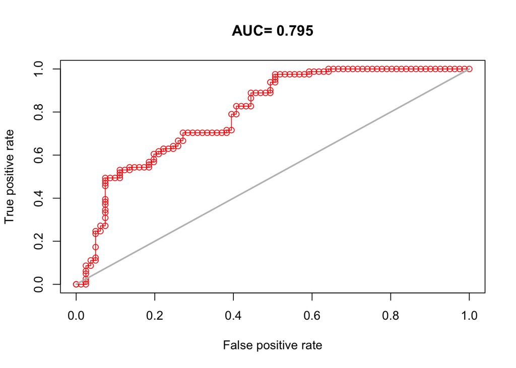

```r
# Isolate the predictor variables for dismo evaluation
eval <- evaluate(p = env.pres[ , safe_vars],
                 a = env.abs[ , safe_vars],
                 model = CRLF.enm)

# Plot ROC curve
plot(eval, 'ROC', main = "ROC Curve: CRLF GLM")
```

Finding: The ROC curve sits well above the null expectation line, indicating a high true positive rate and strong predictive performance.

## Spatial Prediction

Projecting the model back onto the geographic space allows us to visualize the continuous habitat suitability.

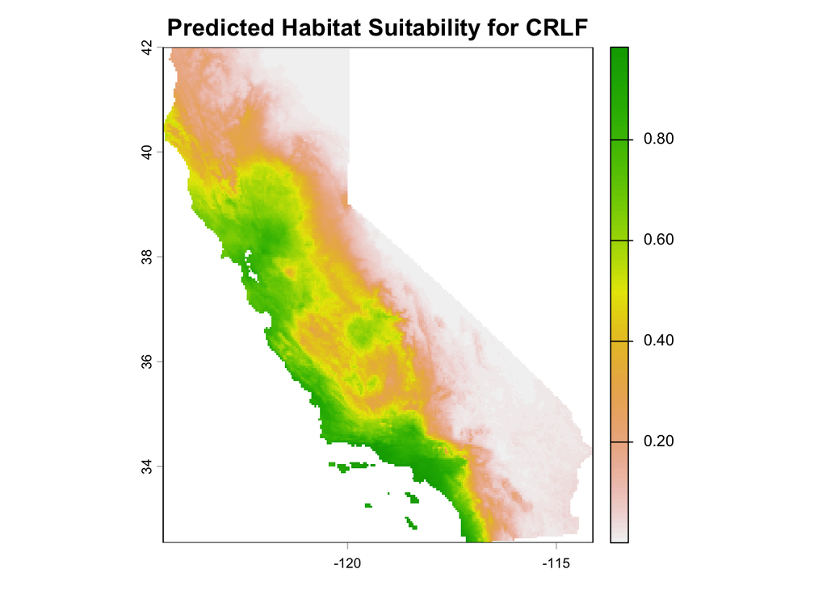

```r
# Generate spatial prediction
enm.pred <- predict(wclim, CRLF.enm, type = "response")

# Plot the suitability map
plot(enm.pred, col = terrain.colors(100, rev = TRUE), main = "Predicted Habitat Suitability for CRLF")
```

## Finding

The Generalized Linear Model (GLM) identifies Precipitation Seasonality (bio15) as the primary environmental constraint for the California red-legged frog (p < 0.001).

# 5. Modeling the California Grizzly and Climate Change (Bioclim)

We apply a similar workflow to the historically extirpated California grizzly bear using a Bioclimatic envelope model (Bioclim). To ensure mathematical consistency across the project, the bear model is restricted to the exact same safe_vars established during the VIF analysis.

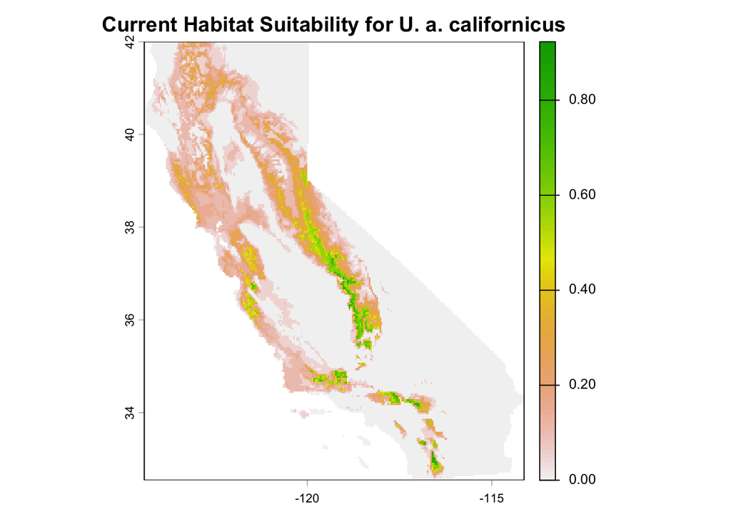

```r
# Load occurrence points
grizzly.df <- read.csv("Ursus_arctos_californicus.csv")
grizzly.occ <- st_as_sf(grizzly.df, coords = c("longitude", "latitude"), crs = 4326)

# Extract environmental values at grizzly locations using the VIF-filtered raster stack
grizzly_matrix <- terra::extract(wclim, vect(grizzly.occ), ID = FALSE)

# Fit the Bioclim ENM
grizzly.bc.enm <- bioclim(grizzly_matrix)

# Predict current spatial suitability
grizzly.bc.pred <- predict(wclim, grizzly.bc.enm)
plot(grizzly.bc.pred, col = terrain.colors(100, rev = TRUE),
     main = "Current Habitat Suitability for U. a. californicus")
```

## Climate Change Projection (2070)

We project the Grizzly Bioclim model onto forecasted WorldClim data for the year 2070.

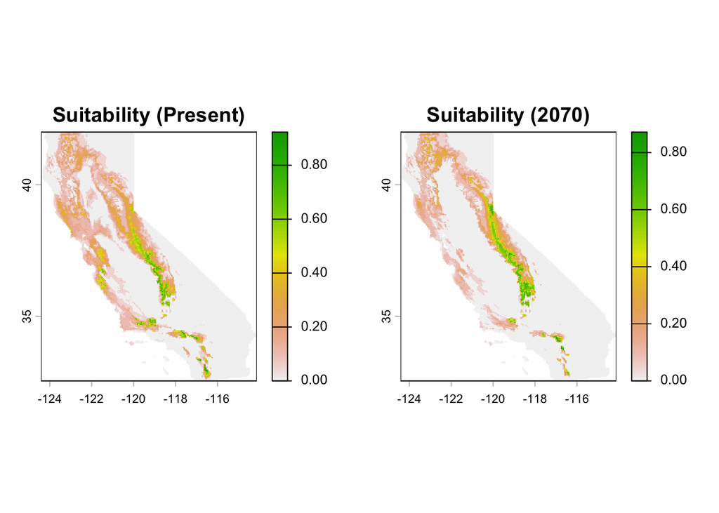

```r
# Download future climate projections (CMIP6) for the year 2070
wclim2070_global <- cmip6_world(model = "MPI-ESM1-2-HR", ssp = "245", time = "2061-2080",
                                var = "bioc", res = 2.5, path = tempdir())
names(wclim2070_global) <- paste0("bio", 1:19)

# Crop and mask to the California boundary
wclim2070 <- mask(crop(wclim2070_global, vect(counties)), vect(counties))

# CRITICAL: Subset the 2070 raster stack to perfectly match our 4 VIF-selected variables
wclim2070 <- subset(wclim2070, safe_vars)

# Project the model into the future
grizzly.bc.2070 <- predict(wclim2070, grizzly.bc.enm)

# Compare Present vs. Future distributions
par(mfrow = c(1, 2))
plot(grizzly.bc.pred, col = terrain.colors(100, rev = TRUE), main = "Suitability (Present)")
plot(grizzly.bc.2070, col = terrain.colors(100, rev = TRUE), main = "Suitability (2070)")
```

## Finding:

Projecting the Bioclim model into the year 2070 reveals a significant geographic contraction and northward shift of suitable environmental conditions for the California grizzly bear. Under future climate scenarios, the distribution of viable environmental conditions for the California grizzly narrows significantly.

# 6. Testing Environmental Niche Overlap

To quantify how similar the environmental niches of the frog and the bear are, we calculate Schoener’s D statistic.

```r
# Generate a Bioclim prediction for the CRLF for direct comparison
CRLF.bc.enm <- bioclim(env.pres[ , safe_vars])
CRLF.bc.pred <- predict(wclim, CRLF.bc.enm)

# Convert rasters and measure overlap
library(raster)
D.obs <- nicheOverlap(raster(CRLF.bc.pred), raster(grizzly.bc.pred), stat = "D")
cat("Observed Schoener's D:", D.obs, "\n")
```

```
## Observed Schoener's D: 0.3114177
```

We generate a null distribution via random permutations within their respective spatial convex hulls to test significance.

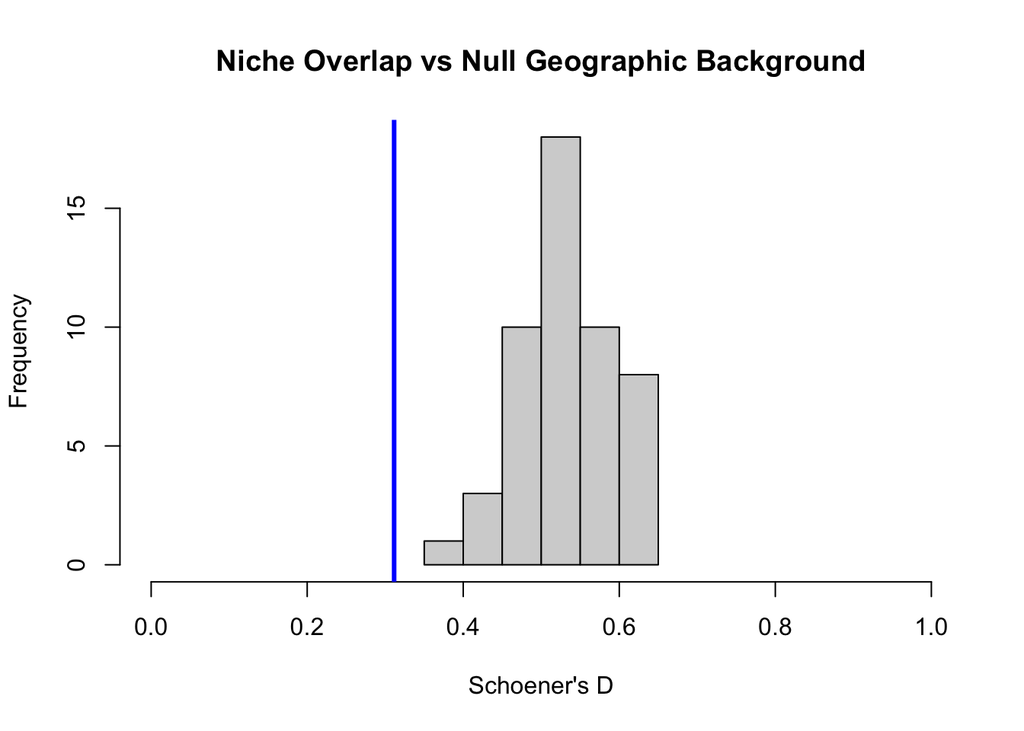

```r
# Generate spatial extents natively with sf
CRLF.range <- st_convex_hull(st_union(CRLF.occ))
grizzly.range <- st_convex_hull(st_union(grizzly.occ))

# Permutation test (n = 50 iterations)
set.seed(789)
D.null <- numeric(50)

for (i in 1:50) {
  CRLF.hull <- st_sample(CRLF.range, size = 50, type = "random")
  grizzly.hull <- st_sample(grizzly.range, size = 50, type = "random")

  CRLF.enm.null <- bioclim(terra::extract(wclim, vect(CRLF.hull), ID = FALSE))
  grizzly.enm.null <- bioclim(terra::extract(wclim, vect(grizzly.hull), ID = FALSE))

  CRLF.pred.null <- predict(wclim, CRLF.enm.null)
  grizzly.pred.null <- predict(wclim, grizzly.enm.null)

  D.null[i] <- nicheOverlap(raster(CRLF.pred.null), raster(grizzly.pred.null), stat = "D")
}

# Plot the null distribution against the observed overlap
par(mfrow = c(1, 1))
hist(D.null, main = "Niche Overlap vs Null Geographic Background",
     xlim = c(0, 1), xlab = "Schoener's D")
abline(v = D.obs, col = "blue", lwd = 3)
```

# Conclusion

The spatial analysis revealed that the niche overlap between the California grizzly bear and the California red-legged frog (indicated by the blue line) is significantly less than expected by chance.

While both species are endemic to California, their distributions are driven by fundamentally different abiotic factors.